# Problem set 1: Berryman, chapters 1–3

## Chapter 1. Dynamics: theoretical ecoology and the rules of change

Deer feed on certain woody shrubs and in so doing can severely reduce their abundance. Shrubs and trees compete with each other for space, sunlight, nutrients, and water. Therefore, the more trees the less shrubs and vice versa. Shrubs, of course, are good for deer, but so are trees, for they provide protection. Draw the feedback structure of this system. How many feedback processes are there and are they negative or positive? Describe these feedback processes and explain how this system can be stabilized.

> Image drawn by hand:

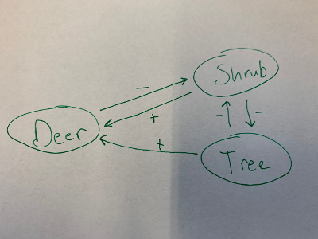

> A simple way to draw this in R:

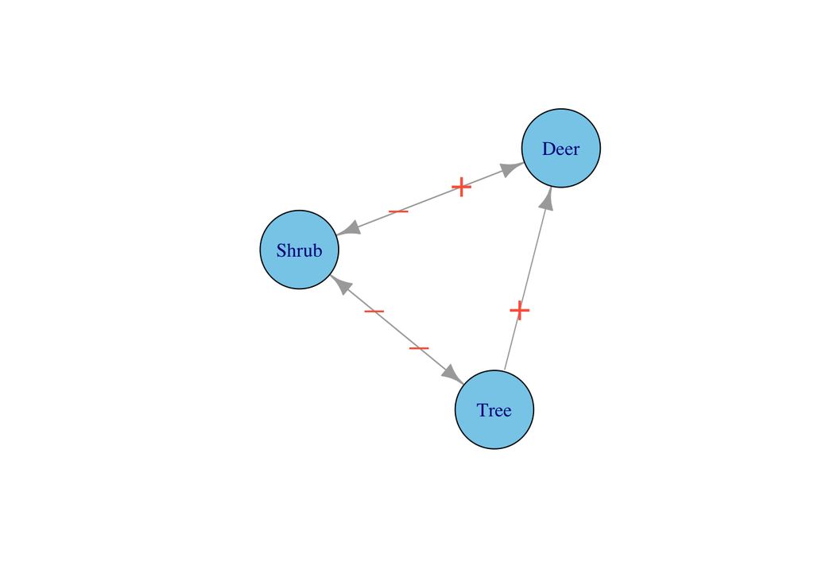

> If we increase the population of deer, that would decrease shrub abundance, increase tree abundance, and therefore increase deer abundance. This is positive feedback.  
> If we increase the abundacne of shrubs, that would decrease the adundance of trees and increase the abudance of deer. But there is an indirect effect of trees on deer, so an increase shrubs would simulaneously decrease deer abundance that would increase shrub abundance.  
> If we increase the abundacne of trees, that would increase the abundance of deer and decrease the abundance of shrubs. But there is an indirect effect of deer on shrubs, so an increase in trees would further decrease the negative effect on shrubs through the deer.

## Chapter 2. Population: the central concept

2.1. 758 elk spend 3 months each winter in a 5 hectare feed lot. These elk are known to range over a watershed of 1230 hectares. What is the absolute size of the population and what is its density?

2.2. A scientist sampled the white grubs in a 3.4 hectare pasture by taking 200 randomly located 1 decimeter (= 10 square centimeters) soil cores. He counted 7564 white grubs in these samples. Calculate the density of white grubs per square meter of soil, per hectare, and the absolute population in the pasture.

> There are 7564 white grubs in 200 samples of 10 square centimeters, which is a sampe of 2,000 square centimeters. There are 10,000 square centemeters in a square meter, meaning the 2,000 square centimeter sample is 1/5 of the area of a square meter. So, 7564 white grubs times 5 = $3.782\times 10^{4}$. There are 10,000 square meteres in a hectare, so $3.782\times 10^{4}$ times 10,000 = $3.782\times 10^{8}$. To determine the absolte population in the pasture that is 3.4 ha, then we multiply our white grubs / ha by 3.4, which is $1.28588\times 10^{9}$.

2.3. The elk population discussed above produced 58 calves in 1990 but only 22 were alive by 1990 December 30. In addition, 37 yearling and older elk died during 1990. What was the per capita birth and death rate and the logarithmic net per capita rate of change (R) over the year? Is this elk population increasing?

**Note**: Remember that elk have sexes, so let’s assume that the female:male is 1:1.

## Chapter 3. The first principle: exponential growth

3.1. If you have $10,000 in the bank at 10% annual interest rate, how much will you have in 10 years if the interest is compounded at the end of each year? What is the relationship between the interest rate and population parameters $G$, $R$, $B$, and $D$?

3.2. Simulate the dynamics of a population for 10 years using equation (3.13) when the initial density is 10 individuals, the per capita rate of change is $R = 0.8$ and the standard deviation is zero. Plot the trajectory on both arithmetic and logarithmic scales.

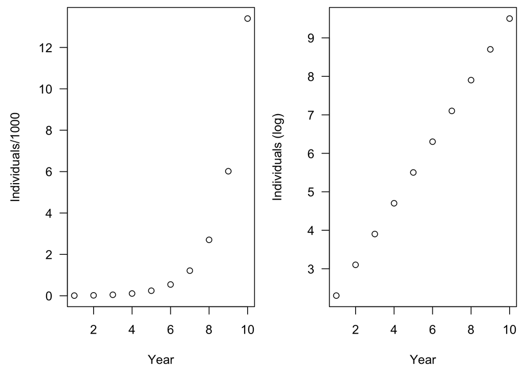

> ```r
> # Create an empty vector for 10 years
>   years <- 10
>   year_vec <- 1:years
>   N_vec <- rep(x = NA, times = years)
> # Set the initial population size at the first year
>   N_vec[1] <- 10
> # Set the parameters
>   R <- 0.8
>   s <- 0
> # Write a "loop" that iterates with "i", in this case, taking the value of every year
>   for (i in 2:years) {
>     Ntm1 <- N_vec[i - 1]
>     Z <- rnorm(n = 1, mean = 0, sd = s)
>     Nt <- Ntm1*exp(R + Z)
>     N_vec[i] <- Nt
>   }
> # Plot
>   par(mfrow = c(1, 2), mar = c(4.5, 4.5, 0.5, 0.5), las = 1)
>   plot(x = year_vec, y = N_vec/1000, xlab = "Year", ylab = "Individuals/1000")
>   plot(x = year_vec, y = log(N_vec), xlab = "Year", ylab = "Individuals (log)")
> ```

3.3. Simulate the dynamics of a population governed by equation (3.13) under the same conditions as before but with the standard deviation 0.2. Plot the trajectory on both arithmetic and logarithmic scales.

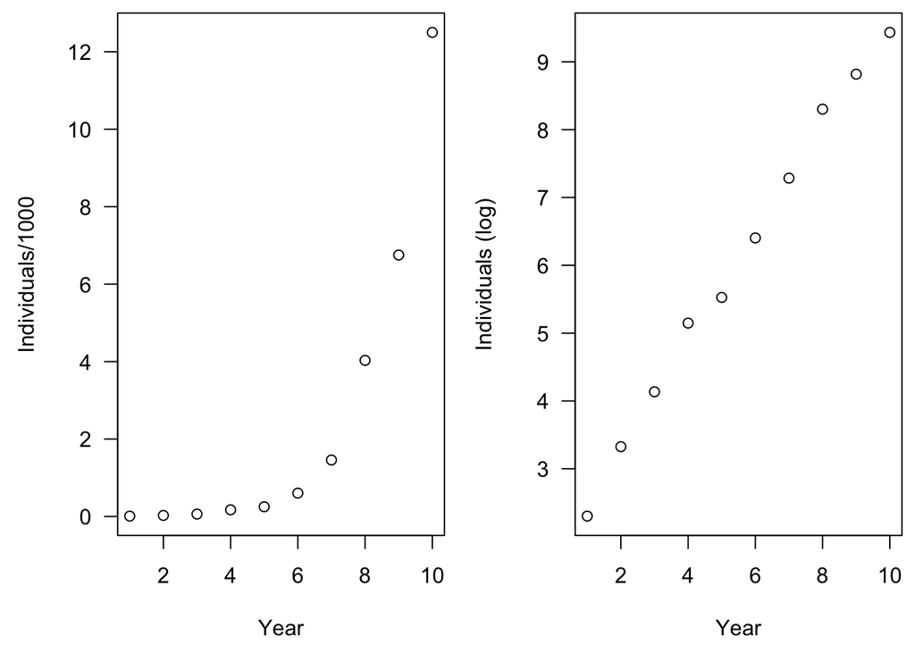

> ```r
> # Create an empty vector for 10 years
>   years <- 10
>   year_vec <- 1:years
>   N_vec <- rep(x = NA, times = years)
> # Set the initial population size at the first year
>   N_vec[1] <- 10
> # Set the parameters
>   R <- 0.8
>   s <- 0.2
> # Write a "loop" that iterates with "i", in this case, taking the value of every year
>   for (i in 2:years) {
>     Ntm1 <- N_vec[i - 1]
>     Z <- rnorm(n = 1, mean = 0, sd = s)
>     Nt <- Ntm1*exp(R + Z)
>     N_vec[i] <- Nt
>   }
> # Plot
>   par(mfrow = c(1, 2), mar = c(4.5, 4.5, 0.5, 0.5), las = 1)
>   plot(x = year_vec, y = N_vec/1000, xlab = "Year", ylab = "Individuals/1000")
>   plot(x = year_vec, y = log(N_vec), xlab = "Year", ylab = "Individuals (log)")
> ```